```python
import os
import sys
sys.path.append("..")
import phytebyte as pb
from phytebyte.bioactive_cmpd.sources import chembl
```

# Choice of clustering model

As a part of the model training process, positive examples will be clustered in order to understand whether there are distinct sets of bioactive compound "classes". These clusters will be modeled separately and the results joined at the end so as to not create conflicting signals in the model training process.

Choice of clustering algorithm: there is a good (though biased) discussion of potential clustering algorithms [here](http://hdbscan.readthedocs.io/en/latest/comparing_clustering_algorithms.html), which steps through some of the main characteristics that are desirable in an algorithm and compares pros/cons.

We do not necessarily have a good idea *a priori* as to what properties our fingerprint data have or what shapes the compound sets are likely to form in high-dimensional space. However we do know a few things:

- Though we may be able to perform checks using prior knowledge on input drug sets, we don't want to assume for this step that we know the number of clusters, so any method we choose should have some ability to "help" with this decision. On a related note, we should be able to extract some sort of metric as to whether there are multiple clusters at all.
- "Don't be wrong": for this use case, it may be better to avoid classifying a given molecule than to allow it to belong to the nearest class. It could create unwanted noise for that class's model, and its information can be incorporated in other ways (e.g. using a Tanimoto approach).
- The feature space will typically be at least the size of an FP2 fingerprint (1024 bits), so speed could be a limiting factor.

Given the third point, we can remove slow methods from our search altogether. The HDBSCAN fellows (of the post linked above) have conveniently benchmarked the performance of the same set of Python clustering implementations [here](http://hdbscan.readthedocs.io/en/latest/performance_and_scalability.html#). At least in terms of scaling with the number of data points (note: not our limitation here), only three methods do reasonably well: K-means variants, agglomerative clustering variants, and DBSCAN variants.

Unapologetically stealing their code and modifying it somewhat to compare feature sizes rather than data point numbers, we have the following clustering benchmark algorithm, which generates and uses toy datasets with Gaussian clusters:

```python
import numpy as np
import pandas as pd
import sklearn.cluster
import sklearn.datasets
import fastcluster
import hdbscan
import time


def benchmark_algorithm(dataset_dimensions, cluster_function, function_args, function_kwds,
                        dataset_size=500, dataset_n_clusters=2, max_time=10, sample_size=2):

    # Initialize the result with NaNs so that any unfilled entries
    # will be considered NULL when we convert to a pandas dataframe at the end
    result = np.nan * np.ones((len(dataset_dimensions), sample_size))
    for index, dataset_dimension in enumerate(dataset_dimensions):
        for s in range(sample_size):
            # Use sklearns make_blobs to generate a random dataset with specified size
            # dimension and number of clusters
            data, labels = sklearn.datasets.make_blobs(n_samples=dataset_size,
                                                       n_features=dataset_dimension,
                                                       centers=dataset_n_clusters)

            # Start the clustering with a timer
            start_time = time.time()
            cluster_function(data, *function_args, **function_kwds)
            time_taken = time.time() - start_time

            # If we are taking more than max_time then abort -- we don't
            # want to spend excessive time on slow algorithms
            if time_taken > max_time:
                result[index, s] = time_taken
                return pd.DataFrame(np.vstack([dataset_dimension.repeat(sample_size),
                                               result.flatten()]).T, columns=['x','y'])
            else:
                result[index, s] = time_taken

    # Return the result as a dataframe for easier handling with seaborn afterwards
    return pd.DataFrame(np.vstack([dataset_dimensions.repeat(sample_size),
                                   result.flatten()]).T, columns=['x','y'])
```

We can then examine the performance of these algorithms in relation to each other in terms of scaling as the feature space grows.

```python
dataset_feature_sizes = np.arange(10, 1000, 100)

kmeans = sklearn.cluster.KMeans(3)
k_means_data = benchmark_algorithm(dataset_feature_sizes, kmeans.fit, (), {})

agglomerative = sklearn.cluster.AgglomerativeClustering(10)
agg_data = benchmark_algorithm(dataset_feature_sizes,
                               agglomerative.fit, (), {}, sample_size=4)

fastclust_data = benchmark_algorithm(dataset_feature_sizes,
                                     fastcluster.linkage_vector, (), {})

dbscan = sklearn.cluster.DBSCAN(eps=1.25)
dbscan_data = benchmark_algorithm(dataset_feature_sizes, dbscan.fit, (), {})

hdbscan_ = hdbscan.HDBSCAN()
hdbscan_data = benchmark_algorithm(dataset_feature_sizes, hdbscan_.fit, (), {})
```

```
Text(0,0.5,'Clustering run time (s)')
```

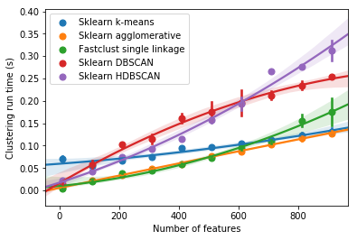

```python
import seaborn as sns
import matplotlib.pyplot as plt
%matplotlib inline

sns.regplot(x='x', y='y', data=k_means_data, order=2, label="Sklearn k-means", x_estimator=np.mean)
sns.regplot(x='x', y='y', data=agg_data, order=2, label="Sklearn agglomerative", x_estimator=np.mean)
sns.regplot(x='x', y='y', data=fastclust_data, order=2, label="Fastclust single linkage", x_estimator=np.mean)
sns.regplot(x='x', y='y', data=dbscan_data, order=2, label="Sklearn DBSCAN", x_estimator=np.mean)
sns.regplot(x='x', y='y', data=hdbscan_data, order=2, label="Sklearn HDBSCAN", x_estimator=np.mean)
plt.legend()
plt.gca().set_xlabel("Number of features")
plt.gca().set_ylabel("Clustering run time (s)")
```

Fortunately, it doesn't seem that any of these algorithms take very long at all given similar dimensions to those expected for PhyteByte (~500 samples and ~1000 features). Taking into account the above considerations as well, it seems that DBSCAN might be a good starting point for our analyses, as it can both figure out the appropriate number of clusters (given a size parameter) and is willing to leave data points unclassified. Let's try using DBSCAN again, this time replacing Gaussian blobs with binary features of the type we will be dealing with:

```python
clust1_data = np.random.binomial(n=1, p=np.linspace(0, 1, num=1024), size=(200, 1024))  # Cluster with more bits on near the end
clust2_data = np.random.binomial(n=1, p=np.linspace(1, 0, num=1024), size=(200, 1024))  # Cluster with more bits on near the beginning
clust3_data = np.concatenate((np.random.binomial(n=500, p=0.02, size=(100,500)),  # Cluster with many bits on near the middle
                              np.random.binomial(n=0.98, p=np.linspace(0, 1, num=24), size=(100, 24)),
                              np.random.binomial(n=500, p=0.02, size=(100,500))),
                            axis=1)
fp_like_data = np.concatenate((clust1_data, clust2_data, clust3_data))

%timeit sklearn.cluster.DBSCAN(eps=1.25).fit(fp_like_data)
```

```
410 ms ± 21.4 ms per loop (mean ± std. dev. of 7 runs, 1 loop each)
```

Performance doesn't seem to change much with "more relevant" toy data (~0.5 seconds for this mock typical clustering run). How did DBSCAN do?

```python
from sklearn.decomposition import PCA

def plot_pca(dataset, labels=None, return_coords=False):
    pca_model = PCA(n_components=2).fit(dataset)
    pca_coords = pca_model.transform(dataset)
    if return_coords:
        return pca_coords
    fig = plt.scatter(x=pca_coords[:,0], y=pca_coords[:,1], c=labels)
    plt.xlabel(f"PC1 ({round(pca_model.explained_variance_ratio_[0] * 100, 1)}% variance explained)")
    plt.ylabel(f"PC2 ({round(pca_model.explained_variance_ratio_[1] * 100, 1)}% variance explained)")
    return fig
```

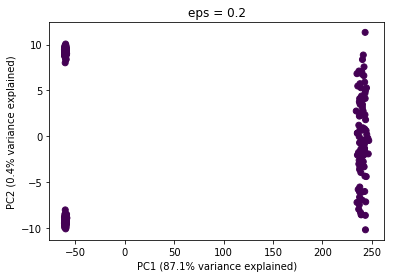

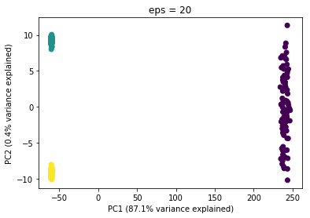

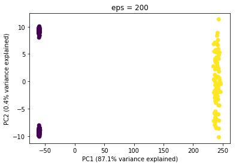

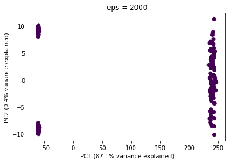

```
Cluster labels across epsilon values:
 {0.2: [-1], 20: [-1, 0, 1], 200: [0, 1], 2000: [0]}
```

```python
unique_labels = {}
for eps in [0.2, 20, 200, 2000]:
    my_cluster = sklearn.cluster.DBSCAN(eps=eps).fit(fp_like_data)
    unique_labels[eps] = list(np.unique(my_cluster.labels_))
    plot_pca(fp_like_data, labels=my_cluster.labels_)
    plt.title(f"eps = {eps}")
    plt.show()

print(f"Cluster labels across epsilon values:\n {unique_labels}")
```

All of this said, this is a highly contrived example, and is probably atypical given the huge discrepancy between cluster "scales" (separation across PC1 which explains almost 90% of the variance vs. separation across PC2 which explains less than 0.5% of the variance). So, it may be more helpful to check out performance on real data.

# Parameter optimization for positive compound clustering

```python
# Prep for using PhyteByte to fetch compounds from ChEMBL
from phytebyte.fingerprinters.base import Fingerprinter

my_source = chembl.ChemblBioactiveCompoundSource(os.environ['CHEMBL_DB_URL'])
my_fingerprinter = Fingerprinter.create('daylight')
```

### HMGCR Example

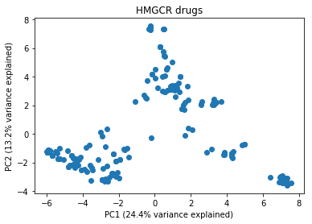

```python
hmgcr_iter = my_source.fetch_with_gene_tgts(['HMGCR'])
hmgcr_list = [bc() for bc in hmgcr_iter]
hmgcr_data = my_fingerprinter.smiles_to_nparrays([bc.canonical_smiles for bc in hmgcr_list])
hmgcr_names = [n.pref_name for n in hmgcr_list]

plot_pca(hmgcr_data)
plt.title("HMGCR drugs")
plt.show()
```

A quick note here on visualization of these clusters: the plots in this notebook have all been generated using PCA. Although other methods exist (e.g. t-SNE) that may be more effective in some applications, they often sacrifice "long-range" distance fidelity (do very different points stay farther apart) for finer-grained distinctions (do somewhat different points stay farther apart). Here, we *do* care about maintaining a conception of large- vs. small-scale substructure, since small-scale substructure is likely less important.

Next, we assess Silhouette scores (metric of modularity used in clustering, range is from -1 to 1, higher is better) across a range of DBSCAN epsilon values to find the putatively optimal epsilon. For some values of epsilon, a non-useful clustering will be returned (all points unclustered or only one "real" cluster) -- we won't include scores for these epsilon levels in the plots.

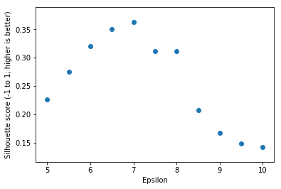

```python
from sklearn.cluster import DBSCAN
from sklearn.metrics import silhouette_score as ss

# def get_ss(eps, data):
#     unique_data = np.unique(data, axis=0)
#     cluster_fit = DBSCAN(eps=eps).fit(unique_data)
#     real_clusters = cluster_fit.labels_ != -1
#     if all(real_clusters==False):  # No clustering was accomplished
#         return None
#     cluster_options = np.unique(cluster_fit.labels_[real_clusters])
#     if len(cluster_options) == 1:  # Number of "real" clusters must be >1 for SS to make sense
#         return None
#     return ss(unique_data[real_clusters], cluster_fit.labels_[real_clusters])

def get_ss(eps, data):
    unique_data = np.unique(data, axis=0)
    cluster_fit = DBSCAN(eps=eps).fit(unique_data)
    if len(np.unique(cluster_fit.labels_)) == 1:  # Only a single cluster
        return None
    return ss(unique_data, cluster_fit.labels_)

eps_seq = np.arange(5, 15, 0.5)
hmgcr_ss_seq = [get_ss(e, hmgcr_data) for e in eps_seq]
plt.scatter(x=eps_seq, y=hmgcr_ss_seq)
plt.xlabel("Epsilon")
plt.ylabel("Silhouette score (-1 to 1; higher is better)")
plt.show()
```

The optimal epsilon values appears to be approximately 7. What do our HMGCR drug clusters look like using that value?

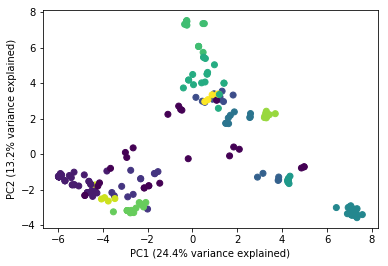

```python
hmgcr_cluster_fit = DBSCAN(eps=7).fit(hmgcr_data)
plot_pca(hmgcr_data, labels=hmgcr_cluster_fit.labels_)
```

It seems DBSCAN did a pretty good job here based on visual inspection. Note also that the point at the top middle was not assigned to a cluster (i.e. it was given a cluster label of -1). One could probably argue as to whether that point belongs in the closest cluster or not, but regardless of this specific case it is worth noting this behavior of the algorithm on real data.

## The crux of this notebook

It's hard to tell from visual inspection whether they are likely biological relevant or just an artifact of "how zoomed in" we are in this plot. It may be that these "clusters" are tight chemical subspaces explored by different drug companies based on their IP, while all of them share the same basic mode of bioactivity. In this case, it is certainly to our advantage to model them all together.

Ideally, we can find a value of epsilon that is generally consistent in resolving biologically relevant subsets. Finding this value will require guidance using prior biological knowledge.

```python
import re

def get_unique_names(bcs, reg_exp=None):
    # Given a list of BioactiveCmpds, return the unique pref_names and their indices
    nms = [bc.pref_name if bc.pref_name is not None else None
           for bc in bcs]
    if reg_exp:
        return np.unique([n for n in nms
                          if n is not None and re.search(reg_exp, n)],
                         return_index=True)
    else:
        return np.unique([n for n in nms if n is not None], return_index=True)
```

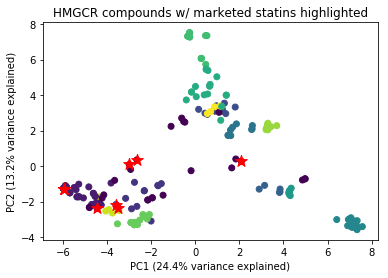

```python
hmgcr_coords = plot_pca(hmgcr_data, return_coords=True)
statin_names, statin_idxs = get_unique_names(hmgcr_list, reg_exp=r'STATIN')

plot_pca(hmgcr_data, labels=hmgcr_cluster_fit.labels_)
plt.scatter(hmgcr_coords[statin_idxs,0], hmgcr_coords[statin_idxs,1],
            c="red", s=150, marker="*")
plt.title("HMGCR compounds w/ marketed statins highlighted")
plt.show()
```

What sort of epsilon value is needed to make sure all (or at least most) of these statin points stay in one cluster?

```
eps=5: [ 0  0 -1  0  0 -1 -1 -1 -1  0  0]
eps=6: [ 0  0 -1  0  0 -1 -1 -1 -1  0  0]
eps=7: [ 0  0  1  0  0 -1  1 -1 -1  0  0]
eps=8: [ 0  0  0  0  0 -1  0  6 -1  0  0]
eps=9: [ 0  0  0  0  0 -1  0  1 -1  0  0]
eps=10: [0 0 0 0 0 0 0 1 0 0 0]
```

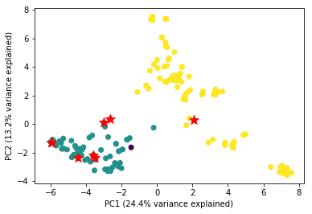

```python
# Print the cluster labels for marketed statins for a series of eps values
# Note: epsilon values above 10 don't produce any clustering (which is OK!)
for eps in np.arange(5, 11):
    cluster_fit = DBSCAN(eps=eps).fit(hmgcr_data)
    print(f'eps={eps}:', cluster_fit.labels_[idxs])
cluster_fit = DBSCAN(eps=10).fit(hmgcr_data)
plot_pca(hmgcr_data, labels=cluster_fit.labels_)
plt.scatter(hmgcr_coords[statin_idxs,0], hmgcr_coords[statin_idxs,1],
            c="red", s=150, marker="*")

plt.show()
```

An epsilon value of 10 looks like it could be interesting. It separates all but one of the marketed statins from the rest of the data points while being higher than the "Silhouette-optimal" epsilon value (good to be conservative -- when in doubt, don't subdivide).

```python
import pandas as pd
from adjustText import adjust_text

names_and_clusters = pd.DataFrame({'cluster': cluster_fit.labels_,
                                   'drug_name': hmgcr_names})
# Only a single pref_name available at the moment
```

## ACE Example

```python
ace_iter = my_source.fetch_with_gene_tgts(['ACE'])
ace_list = [bc() for bc in ace_iter]
ace_data = my_fingerprinter.smiles_to_nparrays([bc.canonical_smiles for bc in ace_list])
ace_names = [n.pref_name for n in ace_list]
```

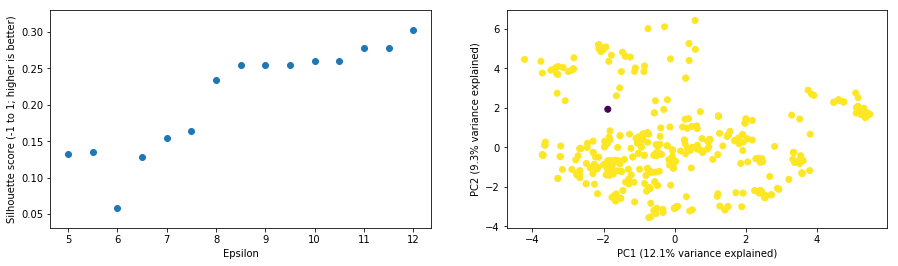

```python
plt.rcParams['figure.figsize'] = [15,4]

ace_ss_seq = [get_ss(e, ace_data) for e in eps_seq]
plt.subplot(121)
plt.scatter(x=eps_seq, y=ace_ss_seq)
plt.xlabel("Epsilon")
plt.ylabel("Silhouette score (-1 to 1; higher is better)")

ace_cluster_fit = DBSCAN(eps=12).fit(ace_data)
plt.subplot(122)
plot_pca(ace_data, labels=ace_cluster_fit.labels_)

plt.show()
```

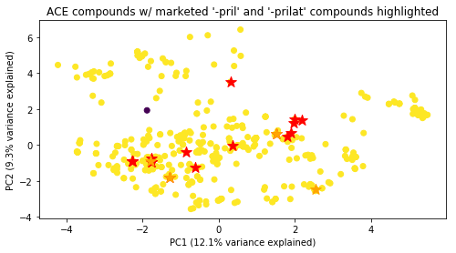

```python
plt.rcParams['figure.figsize'] = [8,4]

ace_coords = plot_pca(ace_data, return_coords=True)
pril_names, pril_idxs = get_unique_names(ace_list, reg_exp=r'PRIL')
prilat_names, prilat_idxs = get_unique_names(ace_list, reg_exp=r'PRILAT')

plot_pca(ace_data, labels=ace_cluster_fit.labels_)
plt.scatter(ace_coords[pril_idxs,0], ace_coords[pril_idxs,1],
            c="red", s=150, marker="*")
plt.scatter(ace_coords[prilat_idxs,0], ace_coords[prilat_idxs,1],
            c="orange", s=150, marker="*")
plt.title("ACE compounds w/ marketed '-pril' and '-prilat' compounds highlighted")
plt.show()
```

Altogether, ACE compounds do not seem highly structured, and the two "classes" of compounds do not seem to segregate in the space of the first two PCs.

## CETP Example

```python
cetp_iter = my_source.fetch_with_gene_tgts(['CETP'])
cetp_list = [bc() for bc in cetp_iter]
cetp_data = my_fingerprinter.smiles_to_nparrays([bc.canonical_smiles for bc in cetp_list])
cetp_names = [n.pref_name for n in cetp_list]
```

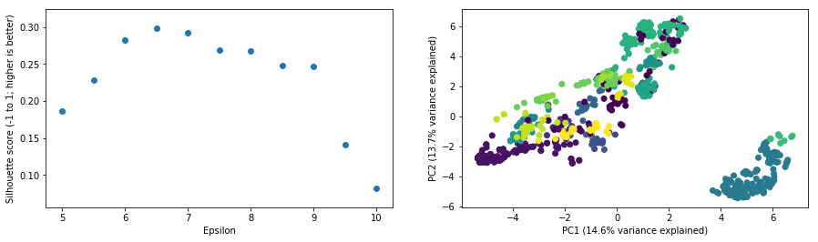

```python
plt.rcParams['figure.figsize'] = [15,4]

cetp_ss_seq = [get_ss(e, cetp_data) for e in eps_seq]
plt.subplot(121)
plt.scatter(x=eps_seq, y=cetp_ss_seq)
plt.xlabel("Epsilon")
plt.ylabel("Silhouette score (-1 to 1; higher is better)")

cetp_cluster_fit = DBSCAN(eps=6.5).fit(cetp_data)
plt.subplot(122)
plot_pca(cetp_data, labels=cetp_cluster_fit.labels_)

plt.show()
```

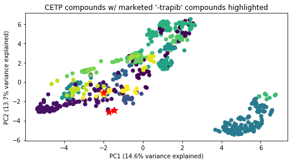

```python
plt.rcParams['figure.figsize'] = [8,4]

cetp_coords = plot_pca(cetp_data, return_coords=True)
trapib_names, trapib_idxs = get_unique_names(cetp_list, reg_exp=r'TRAPIB')

plot_pca(cetp_data, labels=cetp_cluster_fit.labels_)
plt.scatter(cetp_coords[trapib_idxs,0], cetp_coords[trapib_idxs,1],
            c="red", s=150, marker="*")
plt.title("CETP compounds w/ marketed '-trapib' compounds highlighted")
plt.show()
```

Although there is an appealing appearance of two distinct clusters in the PC plot, it doesn't seem that DBSCAN finds exactly these clusters -- the group on the side is fairly isolated, but it seems there is much more going on in the ~70% of variation that is unexplained by these axes.

## MAOA Example

```python
maoa_iter = my_source.fetch_with_gene_tgts(['MAOA'])
maoa_list = [bc() for bc in maoa_iter]
maoa_data = my_fingerprinter.smiles_to_nparrays([bc.canonical_smiles for bc in maoa_list])
maoa_names = [n.pref_name for n in maoa_list]
```

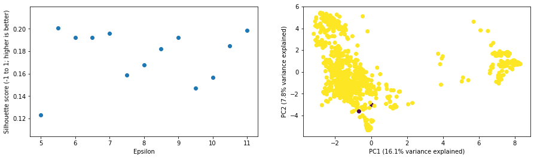

```python
plt.rcParams['figure.figsize'] = [15,4]

maoa_ss_seq = [get_ss(e, maoa_data) for e in eps_seq]
plt.subplot(121)
plt.scatter(x=eps_seq, y=maoa_ss_seq)
plt.xlabel("Epsilon")
plt.ylabel("Silhouette score (-1 to 1; higher is better)")

maoa_cluster_fit = DBSCAN(eps=11).fit(maoa_data)
plt.subplot(122)
plot_pca(maoa_data, labels=maoa_cluster_fit.labels_)

plt.show()
```

# Conclusions and outstanding questions

- DBSCAN has several advantages that are helpful in our use case, and the implementation in scikit-learn performs at quite a reasonable speed.
- It seems that effective epsilon (size parameter) values for DBSCAN stay in a reasonable range for our consistent expected feature set (a 1024-bit vector). The relevant range is approximately 6-12 units.
- Clustering of different drug sets did not successfully find robust clusters, at least for the four common drug targets tested here. Visual analysis of principal component plots did not show complete separation between clusters even after parameter optimization, and silhouette scores were quite modest (optimal values 0.2-0.35, with a theoretical maximum of 1). This could suggest a problem with the clustering method, but it is quite possible that there simply is not a clear set of underlying clusters in these datasets.
- For our application, we would not like to separate compounds into different models unless there is such a meaningful difference between clusters (biologically and computationally) that models combining their information would be less effective. So, one approach would be to create a silhouette score threshold under which we don't use the clustering. As an example:
  - Run DBSCAN at eps = {0.1,6,8,10,12,100} (0.1 and 100 to ensure the we are not missing something important at a highly different scale).
  - Calculate silhouette scores for each of these clusterings.
  - If the maximum silhouette value applies to either 0.1 or 100, flag the result because something may be wrong.
  - If the maximum silhouette value is below 0.5, leave the compounds in a single cluster.
  - Otherwise, pass the discovered clusters on to model training.
- Would it be better to choose a rigid epsilon that is consistent across different drugs? This value could be set to be high (more "conservative") such that we avoid unwanted subclusterings that only provide minor benefit.
- It would be helpful to find an example of a drug target known to have several unique classes of inhibitors as a positive control (to understand what epsilon value achieves proper clustering for that example and what silhouette score such a clustering returns).
- Methods like DBSCAN and HDBSCAN can and do leave data points unclustered if they don't fit well into the current set of clusters. Would we rather use an algorithm like this to remove potential noise and not include those "outliers" in training, or do we think they contain important signal? If we include them, do we force them into the nearest cluster, model the set of "misfits" as an independent group, or use high-stringency Tanimoto comparisons to these misfits to complement the model-based hits from more robust clusters?